# Homework 4. Time series (100 points)

The submitted files must include pdf-s with your answers along with all R scripts. For example:

- Student A submitted:
  - Homework4.pdf - final report containing all answers
  - Homework4.Rmd - R-markdown files with student solutions

No pdf report - no grade. If you experience difficulties with knitting, combine your answers in Word and any other editor and produce pdf-file for grading.

No R scripts - 50 % reduction in grade if relative code present in pdf- report, 100% reduction if no such code present.

Reports longer than 40 pages are not going to be graded.

## Question1

1. The plastics data set (see plastics.csv) consists of the monthly sales (in thousands) of product A for a plastics manufacturer for five years. (Total 32 points)

1.1 Read csv file and convert to tsible with proper index (2 points)

```r
plastics_df<- read.csv("plastics.csv")

mutate(plastics_df,date=yearmonth(date)) %>%
tsibble(index=date) ->plastics_df

head(plastics_df)
```

| date | sale |
| --- | --- |
| 1995 Jan | 742 |
| 1995 Feb | 697 |
| 1995 Mar | 776 |
| 1995 Apr | 898 |
| 1995 May | 1030 |
| 1995 Jun | 1107 |

1.2 Plot the time series of sales of product A. Can you identify seasonal fluctuations and/or a trend-cycle? (2 points) #Yes, Sales exhibit a definite seasonal trend, increasing in the summer and falling off in the winter.

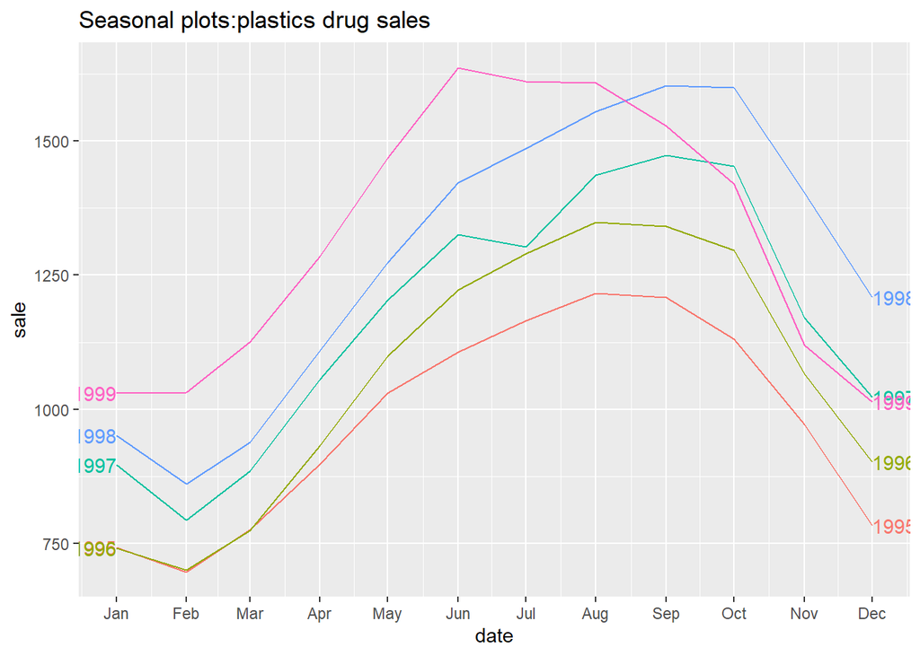

```r
plastics_df %>% gg_season(sale, labels = "both") +
  labs(y = "sale", title = "Seasonal plots:plastics drug sales")
```

1.3) Use a classical multiplicative decomposition to calculate the trend-cycle and seasonal components. Plot these components. (4 points)

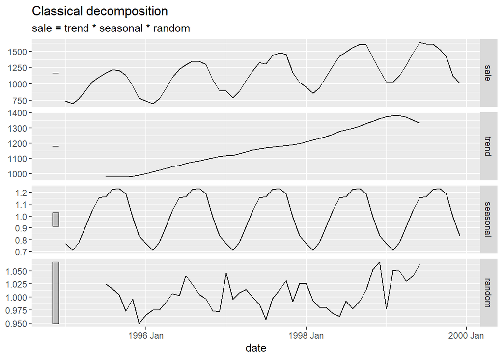

```r
model = plastics_df %>% model(classical_decomposition(sale, type='m'))
components(model) %>% autoplot()
```

1.4 Do the results support the graphical interpretation from part a? (2 points) #Yes, it support the observations.

1.5 Compute and plot the seasonally adjusted data. (2 points)

```
## Plot variable not specified, automatically selected `.vars = season_adjust`
```

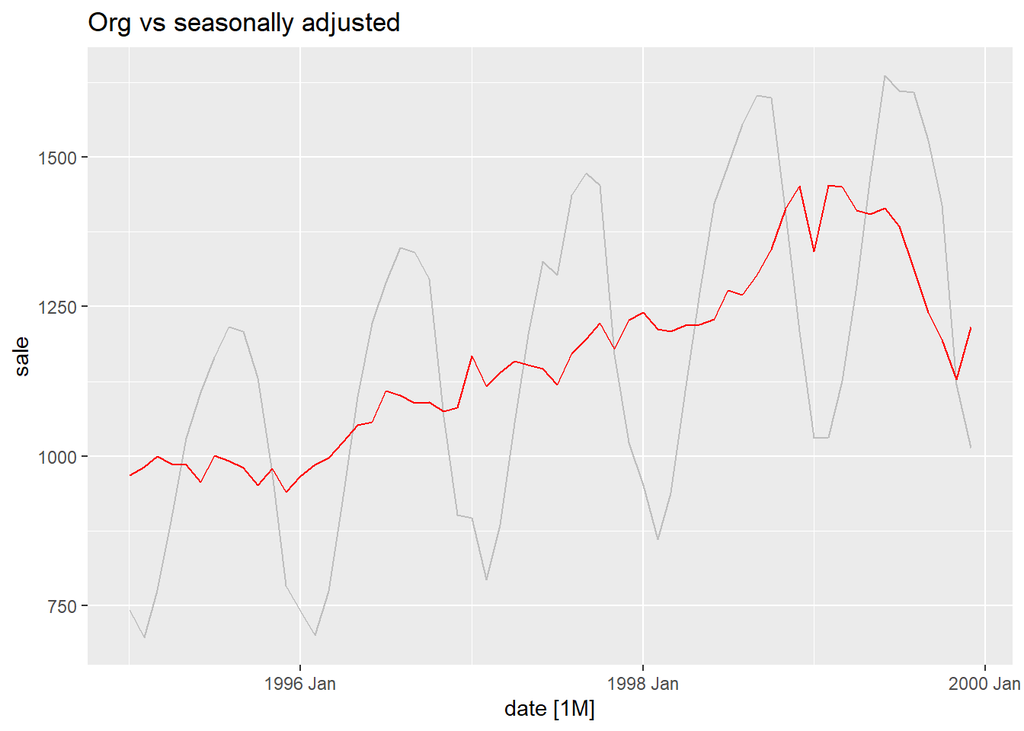

```r
adjusted <- model %>% components() %>% select(season_adjust)
plastics_df %>%
  autoplot(sale, color = "gray") +
  autolayer(adjusted, series = "Seasonally Adjusted", color = "red") +
  labs(
    title = "Org vs seasonally adjusted",
  )
```

1.6 Change one observation to be an outlier (e.g., add 500 to one observation), and recompute the seasonally adjusted data. What is the effect of the outlier? (2 points) # The outlier has a good effect on the graph because we see could a spike. It may increase average value of the data.

```
## Plot variable not specified, automatically selected `.vars = season_adjust`
```

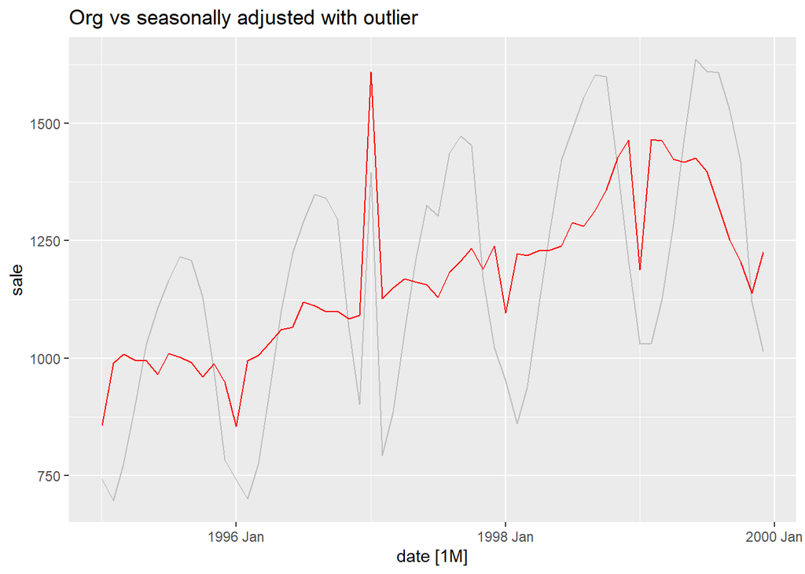

```r
plastics_df_new <- plastics_df

plastics_df_new$sale[25] <- plastics_df_new$sale[25] + 500
new_model <- plastics_df_new %>% model(classical_decomposition(sale, type='m'))

plastics_df_new %>%
  autoplot(sale, color="gray") +
  autolayer(select(components(new_model),season_adjust),color = "red") +
  labs(
    title = "Org vs seasonally adjusted with outlier",
  )
```

tip: use autoplot to plot original and add outlier plot with autolayer

1.7 Does it make any difference if the outlier is near the end rather than in the middle of the time series? (2 points) #If the outlier is present at end then there is no significant impact, however if the outlier is at middle there could be impact towards the trend of the timeseries.

1.8 Let’s do some accuracy estimation. Split the data into training and testing. Let all points up to the end of 1998 (including) are training set. (2 points)

```r
train <- plastics_df %>%
  filter(date <= yearmonth("1998-12"))

test <- plastics_df %>%
  filter(date > yearmonth("1998-12"))
```

1.9 Using training set create a fit for mean, naive, seasonal naive and drift methods. Forecast next year (in training set). Plot forecasts and actual data. Which model performs the best. (4 points)

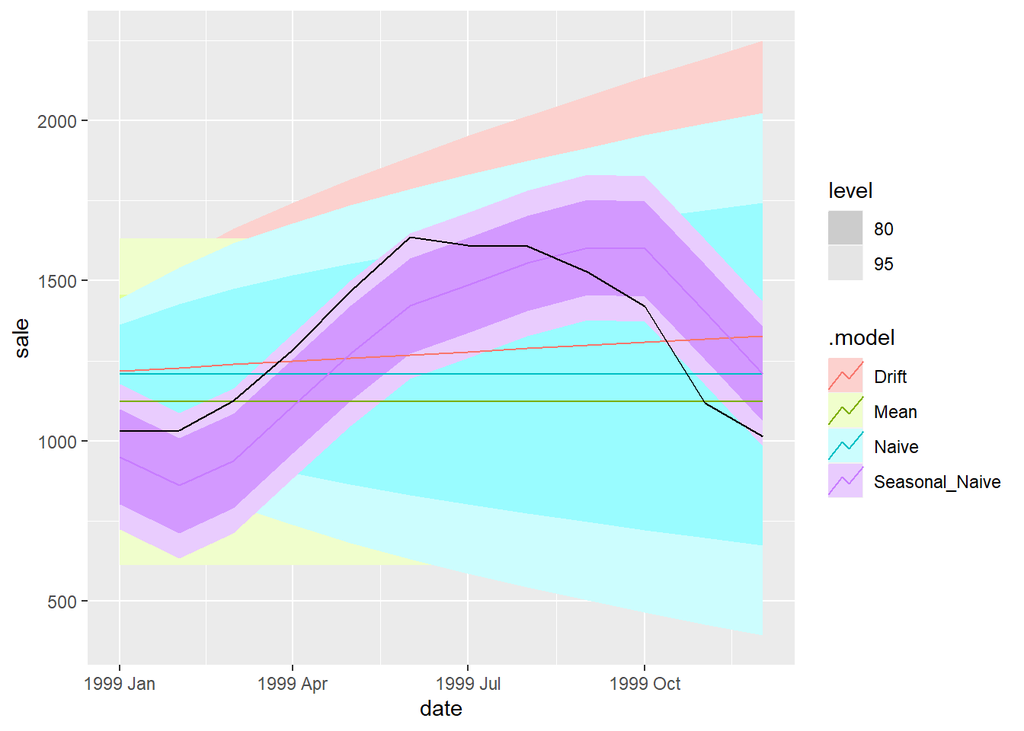

```r
fit <- train %>%
  model(
    Mean = MEAN(sale),
    Naive = NAIVE(sale),
    Seasonal_Naive = SNAIVE(sale),
    Drift = RW(sale ~ drift())
  )
pred <- forecast(fit,h = 12)
autoplot(pred,test)
```

1.10 Repeat 1.9 for appropriate EST. Report the model. Check residuals. Plot forecasts and actual data. (4 points)

```r
fit_ets <- train %>%
  model(ets_auto = ETS(sale))

report(fit_ets[1])
```

```
## Series: sale
## Model: ETS(M,Ad,M)
##   Smoothing parameters:
##     alpha = 0.9047366
##     beta  = 0.06929627
##     gamma = 0.0001231683
##     phi   = 0.9743239
##
##   Initial states:
##      l[0]     b[0]      s[0]     s[-1]    s[-2]    s[-3]    s[-4]    s[-5]
##  941.1877 10.06324 0.8274347 0.9880802 1.187251 1.233995 1.230671 1.171347
##     s[-6]    s[-7]     s[-8]     s[-9]    s[-10]    s[-11]
##  1.139274 1.040372 0.9093021 0.7774054 0.7109808 0.7838869
##
##   sigma^2:  9e-04
##
##      AIC     AICc      BIC
## 533.9618 557.5480 567.6434
```

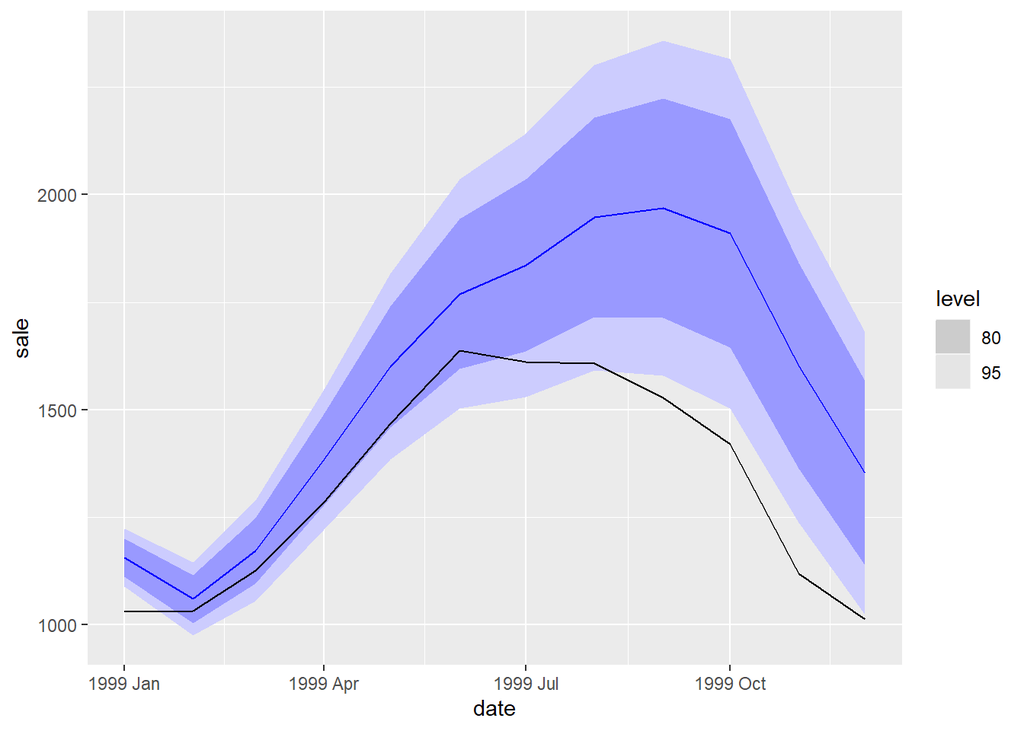

```r
fit_ets <- fit_ets[1]


pred_ets <- forecast(fit_ets, h = 12)

autoplot(pred_ets,test)
```

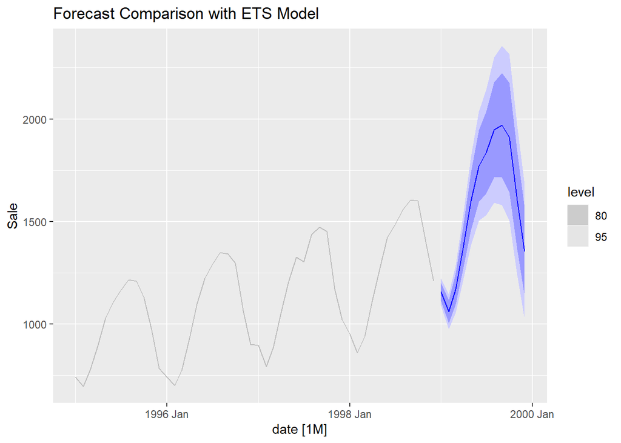

```r
autoplot(train, sale, color = "gray") +
  autolayer(pred_ets, series = "ETS", color = "blue") +
  labs(title = "Forecast Comparison with ETS Model",
       y = "Sale",
       color = "Forecast Method")
```